# 4545 Team League: Season 29

[figure not shown]

### Overview

This [season’s](https://www.lichess4545.com/team4545/season/29/summary/) games were played between 24 January 2022 and 21 March 2022.

628 players participated, 170 (27%) of whom were new to the league.

50 teams played 200 matches over the season’s eight weeks. 13 matches (6%) were drawn, and 57 (28%) were won by just a single point.

In all, 1,878 games were played over the season. The season’s ‘unplayed pairing’ rate was 6.1%.[^1]

White won 841 games (44.8%), 257 games (13.7%) were drawn, and Black won 738 games (39.3%). The right-hand chart shows game results by colour for each board or average rating band.[^2]

[figure not shown]

### Final standings

*Team rosters ordered by number of games played (shown in brackets)*

1st place

[Adult Decliners](https://www.lichess4545.com/team4545/season/29/team/46/)

2nd place

[You Brought a Bishop to a Knight Fight](https://www.lichess4545.com/team4545/season/29/team/2/)

3rd place

[Aagaard’s Army](https://www.lichess4545.com/team4545/season/29/team/32/)

| Gold | Silver | Bronze |
| --- | --- | --- |
| Abolizer (8) | allyrbsrblngtus (8) | AlexMorgenthau (8) |
| KirkD (8) | Chewbacca_Defense (8) | avotoast2 (8) |
| Kjar (8) | destroyer11758 (8) | Pifisch (8) |
| Rolihlahla (8) | Qudit (8) | StoppedClock (8) |
| samuelglats (8) | Seb32 (8) | atbeaty (7) |
| TimothyHa (8) | VicPez (8) | BuckDuck (7) |
| Jputterg (7) | samkellett (7) | DJ-Logan (7) |
| jurica_c (7) | teg (6) | kanakaishou (5) |
| Scarff (7) | adrienb96 (5) | Kingchase (4) |
| izzie26 (6) | Reiscritor (4) | Narski (3) |

[output cut: 8 more lines]

#### How the title race played out

[figure not shown]

**Match stories**

See the twists and turns in every match this season through these PDF visualisations…assuming they’ve already been created and uploaded. [Source script](https://github.com/rahulan-c/lichess4545-stats/blob/main/scripts/plot_match_story.R).

Round 1 | Round 2 | Round 3 | Round 4 | Round 5 | Round 6 | Round 7 | Round 8

### Top players 🎩

#### Board medals

Here are the top player performances on each board (minimum 5 games played).[^3]

| Board | Player(s) | Games | Points | Board Perf. |
| --- | --- | --- | --- | --- |
| 1 | Like-a-hurricane | 5 | 5 | 2989.2 |
| 1 | BuckDuck | 7 | 5.5 | 2469.57142857143 |
| 1 | x420noscope | 5 | 4 | 2447.2 |
| 2 | gearx | 8 | 7.5 | 2529.75 |
| 2 | jantho | 7 | 6 | 2368.85714285714 |
| 2 | Antaniserse | 6 | 5 | 2346.66666666667 |
| 3 | izzie26 | 6 | 6 | 2793.66666666667 |
| 3 | benellis3 | 6 | 5 | 2271.83333333333 |
| 3 | Superfighter | 6 | 4.5 | 2204 |
| 4 | chessnerdbird | 5 | 5 | 2744.2 |

[output cut: 20 more lines]

#### Best scorers

Here’s everyone who achieved a plus score of +5 or higher this season[^4]:

**gearx** (7.5/8), **S1CKone** (7/7), **Scarff** (7/7), **allyrbsrblngtus** (7/8), **atbeaty** (6.5/7), **chessnerdbird** (6/6), **ChessPriyome** (7/8), **izzie26** (6/6), **jkernan7553** (7/8), **King_killer27** (7/8), **SpiteKnight** (7/8), **ThePenguinOfDeath** (6/6), **avotoast2** (6/7), **dogthepanda** (5.5/6), **fake_switch** (6.5/8), **fellchaos** (6/7), **fulmarsky** (6/7), **Herzog51** (6.5/8), **jantho** (6/7), **Like-a-hurricane** (5/5), **rodeo** (6.5/8), **samuelglats** (6/7), **wargoblin** (6.5/8)

Players with plus scores of +6 or better get the **Ace** award.

### Stats - overview

#### Timing 📊

[figure not shown]

#### Length 📊

[figure not shown]

#### Most moves

*Includes games ranked at or above the 90th percentile by number of moves.*

| Rank | Players / Link | Date | Moves |
| --- | --- | --- | --- |
| 1 | gokuba - covton | Fri 11 Feb 2022 | 105 |
| 2 | supermaths - QEDemonstrandum | Sat 26 Feb 2022 | 101 |
| 3 | toluikahn - mumblecoredumbledore | Fri 28 Jan 2022 | 94 |
| 3 | O1189998819991197253 - Toonerer | Sun 13 Mar 2022 | 94 |
| 4 | Tsetsen - x420noscope | Sun 13 Feb 2022 | 93 |
| 5 | eie24 - Mehzinho | Fri 11 Feb 2022 | 92 |
| 6 | Davidc2214 - sideshow_bob | Sun 30 Jan 2022 | 91 |
| 7 | aerdna69 - ba55i5t | Sat 5 Feb 2022 | 90 |
| 7 | levier17 - zADAcLaY | Thu 3 Mar 2022 | 90 |
| 8 | Dawn4365 - ozengnr | Mon 28 Feb 2022 | 89 |

[output cut: 188 more lines]

#### Longest games

*Includes games ranked at or above the 90th percentile by total clock time.*[^5]

| Rank | Players / Link | Date | Total time |
| --- | --- | --- | --- |
| 1 | Tsetsen - x420noscope | Sun 13 Feb 2022 | 3h 36m 26s |
| 2 | Okoros - IsaVulpes | Thu 17 Feb 2022 | 3h 31m 3s |
| 3 | Davidc2214 - sideshow_bob | Sun 30 Jan 2022 | 3h 28m 21s |
| 4 | eie24 - Mehzinho | Fri 11 Feb 2022 | 3h 27m 37s |
| 5 | O1189998819991197253 - Toonerer | Sun 13 Mar 2022 | 3h 26m 58s |
| 6 | pie314271 - liboy | Wed 2 Feb 2022 | 3h 21m 13s |
| 7 | JoseOMG - rojazu | Thu 17 Feb 2022 | 3h 21m 11s |
| 8 | wakeupspaceboy - Pauli314 | Thu 10 Feb 2022 | 3h 18m 42s |
| 9 | levier17 - zADAcLaY | Thu 3 Mar 2022 | 3h 18m 12s |
| 10 | AlanChessy - FlokiTheCat | Thu 27 Jan 2022 | 3h 16m 5s |

[output cut: 188 more lines]

### Stats - by board/rating

#### ACPL and blunder rate 📊

[figure not shown]

#### Lowest combined ACPL

The games with the lowest combined ACPL (including draws).

| Board | Players / Link | Result | Sum ACPL | Date |
| --- | --- | --- | --- | --- |
| 1 | Okoros - IsaVulpes | 1/2-1/2 | 8 | Thu 17 Feb 2022 |
| 2 | gearx - RazorSharpOnly | 1/2-1/2 | 11 | Thu 17 Feb 2022 |
| 3 | Dtdeep - danbock | 1/2-1/2 | 15 | Sun 20 Mar 2022 |
| 4 | KingSlayer78 - JoseOMG | 0-1 | 8 | Sat 12 Feb 2022 |
| 5 | nvasquez - Bone-Collector | 1-0 | 24 | Mon 21 Feb 2022 |
| 6 | LordPericulum - adrienb96 | 1/2-1/2 | 32 | Thu 3 Feb 2022 |
| 7 | VicPyrrhic - amirkhaled21 | 1/2-1/2 | 29 | Sat 5 Mar 2022 |
| 8 | destroyer11758 - ericBG | 1/2-1/2 | 18 | Sat 26 Feb 2022 |
| 9 | dy_lan10 - SlowChess73 | 0-1 | 39 | Sun 13 Mar 2022 |
| 10 | mjodonnell - fulmarsky | 0-1 | 29 | Fri 11 Feb 2022 |

#### Decisive games only

The *decisive* games with the lowest combined ACPL.

| Board | Players / Link | Result | Sum ACPL | Date |
| --- | --- | --- | --- | --- |
| 1 | QEDemonstrandum - Like-a-hurricane | 0-1 | 36 | Wed 16 Mar 2022 |
| 2 | zazziki - TimothyHa | 1-0 | 40 | Sat 29 Jan 2022 |
| 3 | Gustavkar - sgis | 0-1 | 33 | Thu 24 Feb 2022 |
| 4 | KingSlayer78 - JoseOMG | 0-1 | 8 | Sat 12 Feb 2022 |
| 5 | nvasquez - Bone-Collector | 1-0 | 24 | Mon 21 Feb 2022 |
| 6 | theBunglet - ztraynor | 1-0 | 39 | Thu 17 Mar 2022 |
| 7 | lleee - StoppedClock | 0-1 | 35 | Sun 6 Feb 2022 |
| 8 | KirkD - sephiroth87 | 1-0 | 44 | Sun 6 Mar 2022 |
| 9 | dy_lan10 - SlowChess73 | 0-1 | 39 | Sun 13 Mar 2022 |
| 10 | mjodonnell - fulmarsky | 0-1 | 29 | Fri 11 Feb 2022 |

### Openings

#### First moves 📊

[figure not shown]

#### Top openings

All openings played in the season, excluding variations.

| rank | opening.broad | games | perc_w | white_wins | draws | black_wins | mean_eval_after_15 | mean_rating |
| --- | --- | --- | --- | --- | --- | --- | --- | --- |
| 1 | Sicilian Defense | 329 | 51.3677811550152 | 44.3768996960486 | 13.9817629179331 | 41.6413373860182 | 0.594458204334365 | 1882.71276595745 |
| 2 | Caro-Kann Defense | 196 | 52.5510204081633 | 45.4081632653061 | 14.2857142857143 | 40.3061224489796 | 0.54292817679558 | 1802.17091836735 |
| 3 | French Defense | 112 | 56.6964285714286 | 46.4285714285714 | 20.5357142857143 | 33.0357142857143 | 0.745585585585586 | 1863.05357142857 |
| 4 | Queen's Pawn Game | 101 | 59.4059405940594 | 46.5346534653465 | 25.7425742574257 | 27.7227722772277 | 0.583917525773196 | 1772.14851485149 |
| 5 | English Opening | 97 | 58.2474226804124 | 51.5463917525773 | 13.4020618556701 | 35.0515463917526 | 0.599479166666667 | 1876.87628865979 |
| 5 | Queen's Gambit Declined | 97 | 53.0927835051546 | 47.4226804123711 | 11.340206185567 | 41.2371134020619 | 0.566382978723404 | 1852.77319587629 |
| 6 | Italian Game | 75 | 48.6666666666667 | 40 | 17.3333333333333 | 42.6666666666667 | 0.645571428571429 | 1825.67333333333 |
| 6 | Ruy Lopez | 75 | 50.6666666666667 | 44 | 13.3333333333333 | 42.6666666666667 | 0.338472222222222 | 1879.60666666667 |
| 7 | King's Indian Defense | 59 | 57.6271186440678 | 52.5423728813559 | 10.1694915254237 | 37.2881355932203 | 0.444107142857143 | 1884.22033898305 |
| 8 | Indian Defense | 53 | 60.377358490566 | 50.9433962264151 | 18.8679245283019 | 30.188679245283 | 0.702884615384615 | 1834.21698113208 |

[output cut: 66 more lines]

#### Best for White

White’s top-scoring openings, excluding variations. *Minimum 10 games played.*

| rank | opening.broad | games | perc_w | white_wins | draws | black_wins | mean_eval_after_15 | mean_rating |
| --- | --- | --- | --- | --- | --- | --- | --- | --- |
| 1 | Queen's Indian Defense | 15 | 73.3333333333333 | 60 | 26.6666666666667 | 13.3333333333333 | 0.686666666666667 | 1919.3 |
| 2 | Modern Defense | 19 | 65.7894736842105 | 57.8947368421053 | 15.7894736842105 | 26.3157894736842 | 0.636666666666667 | 1763.44736842105 |
| 3 | Vienna Game | 16 | 65.625 | 62.5 | 6.25 | 31.25 | 0.598125 | 1811.0625 |
| 4 | Queen's Gambit Accepted | 16 | 62.5 | 50 | 25 | 25 | 0.177857142857143 | 1805.5 |
| 5 | Benoni Defense | 13 | 61.5384615384615 | 46.1538461538462 | 30.7692307692308 | 23.0769230769231 | 0.506923076923077 | 1866.23076923077 |
| 6 | Indian Defense | 53 | 60.377358490566 | 50.9433962264151 | 18.8679245283019 | 30.188679245283 | 0.702884615384615 | 1834.21698113208 |
| 7 | Queen's Pawn Game | 101 | 59.4059405940594 | 46.5346534653465 | 25.7425742574257 | 27.7227722772277 | 0.583917525773196 | 1772.14851485149 |
| 8 | English Opening | 97 | 58.2474226804124 | 51.5463917525773 | 13.4020618556701 | 35.0515463917526 | 0.599479166666667 | 1876.87628865979 |
| 9 | Neo-Grünfeld Defense | 13 | 57.6923076923077 | 46.1538461538462 | 23.0769230769231 | 30.7692307692308 | 0.292307692307692 | 2015.69230769231 |
| 10 | King's Indian Defense | 59 | 57.6271186440678 | 52.5423728813559 | 10.1694915254237 | 37.2881355932203 | 0.444107142857143 | 1884.22033898305 |

[output cut: 24 more lines]

#### Best for Black

Black’s top-scoring openings, excluding variations. *Minimum 10 games played.*

| rank | opening.broad | games | perc_b | black_wins | draws | white_wins | mean_eval_after_15 | mean_rating |
| --- | --- | --- | --- | --- | --- | --- | --- | --- |
| 1 | Dutch Defense | 24 | 70.8333333333333 | 66.6666666666667 | 8.33333333333333 | 25 | 0.504090909090909 | 1877.20833333333 |
| 1 | Tarrasch Defense | 12 | 70.8333333333333 | 66.6666666666667 | 8.33333333333333 | 25 | 0.719166666666667 | 1911.5 |
| 2 | Semi-Slav Defense | 23 | 63.0434782608696 | 56.5217391304348 | 13.0434782608696 | 30.4347826086957 | 0.400434782608696 | 1930.71739130435 |
| 3 | Grünfeld Defense | 26 | 59.6153846153846 | 53.8461538461538 | 11.5384615384615 | 34.6153846153846 | 0.582692307692308 | 1993.44230769231 |
| 4 | Four Knights Game | 11 | 59.0909090909091 | 45.4545454545455 | 27.2727272727273 | 27.2727272727273 | 0.219090909090909 | 1859.86363636364 |
| 5 | Zukertort Opening | 32 | 54.6875 | 50 | 9.375 | 40.625 | 0.41375 | 1796.359375 |
| 6 | Scotch Game | 45 | 54.4444444444444 | 48.8888888888889 | 11.1111111111111 | 40 | 0.953 | 1801.92222222222 |
| 7 | King's Indian Attack | 17 | 52.9411764705882 | 52.9411764705882 | 0 | 47.0588235294118 | 0.855294117647059 | 1796.70588235294 |
| 8 | Pirc Defense | 29 | 51.7241379310345 | 44.8275862068966 | 13.7931034482759 | 41.3793103448276 | 0.801724137931034 | 1761.3275862069 |
| 9 | Nimzo-Indian Defense | 35 | 51.4285714285714 | 45.7142857142857 | 11.4285714285714 | 42.8571428571429 | 0.463529411764706 | 1899.22857142857 |

[output cut: 24 more lines]

#### Top gambits

The most played gambits over the season.[^6]

| Rank | Name | Games | White score (%) |
| --- | --- | --- | --- |
| 1 | Scotch Gambit | 15 | 43.3333333333333 |
| 2 | Smith-Morra Gambit | 12 | 58.3333333333333 |
| 3 | Queen's Gambit Accepted | 12 | 45.8333333333333 |
| 4 | Benko Gambit | 11 | 36.3636363636364 |
| 5 | Evans Gambit | 8 | 37.5 |
| 6 | Vienna Gambit | 7 | 28.5714285714286 |
| 7 | Polerio Defense (Two Knights) | 5 | 50 |
| 8 | Ruy Lopez: Marshall Attack | 4 | 100 |
| 9 | King's Gambit | 4 | 87.5 |
| 10 | Milner-Barry Gambit | 4 | 75 |

[output cut: 32 more lines]

#### Gambiteers 🤺

The players who enjoyed the most success when playing gambits.[^7] *Includes everyone who scored at least 50 per cent across at least two gambit games.*

| Rank | Player | Games | % Score | W | B | Choices |
| --- | --- | --- | --- | --- | --- | --- |
| 1 | chessnerdbird | 4 | 100 | 3 | 1 | Milner-Barry Gambit, Medusa Gambit, Smith-Morra Gambit |
| 2 | nokiokid | 4 | 50 | 1 | 3 | Wing Gambit, Stafford Gambit |
| 3 | ThePenguinOfDeath | 3 | 100 | 2 | 1 | Blackmar-Diemer Gambit, Stafford Gambit, Rasa-Studier Gambit |
| 4 | FearlessKing64 | 3 | 66.6666666666667 | 3 | 0 | Scotch Gambit, Milner-Barry Gambit |
| 4 | mcqknigh | 3 | 66.6666666666667 | 3 | 0 | Smith-Morra Gambit, Evans Gambit |
| 4 | Rolfomania | 3 | 66.6666666666667 | 1 | 2 | Budapest Defense, Schaeffer Gambit |
| 5 | Davidc2214 | 3 | 50 | 3 | 0 | Scotch Gambit, Alekhine Gambit |
| 6 | BrandrokID | 2 | 100 | 2 | 0 | Smith-Morra Gambit, Anti-Moscow Gambit |
| 6 | Scaredpeach | 2 | 100 | 2 | 0 | Smith-Morra Gambit, Cochrane Gambit |
| 7 | pulsar512b | 2 | 75 | 1 | 1 | Steinitz Countergambit, Queen's Gambit |

[output cut: 4 more lines]

### Openings sunburst 🌞

Click on the image below to see a sunburst plot of all openings played in the season.

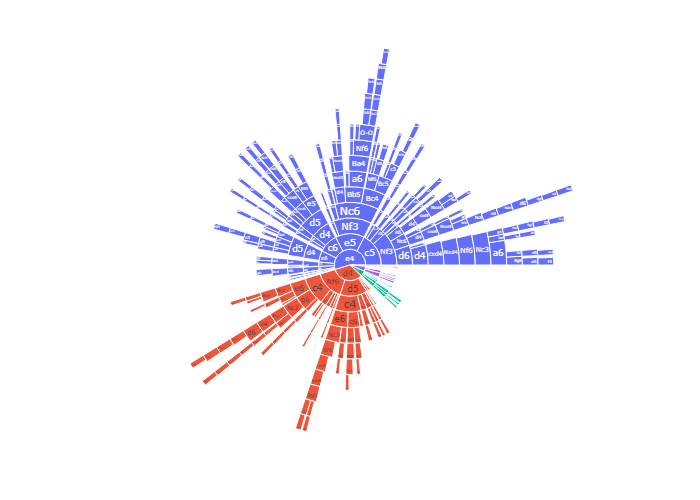

### Awards 🏆

Assorted awards to celebrate the season. See the footnote for more details about each award.[^8]

| Award | Name / Description | Winner(s) | Runner(s)-up |
| --- | --- | --- | --- |
| x | Aces | allyrbsrblngtus, atbeaty, chessnerdbird, ChessPriyome, gearx, izzie26, jkernan7553, King_killer27, S1CKone, Scarff, SpiteKnight, ThePenguinOfDeath |  |
| x | Archbishop of Accuracy | dogthepanda | ChessPriyome, gearx |
| x | Awesome Alt | August_der_Starke, Hindemith, snadyc | amanlikekennyken, Angrybird029, Cannonbait, datcerealbaux, davidthepawn, ekopp2000, FourLanChurro, Like-a-hurricane, lioxxx, mini_karpov, prostidude, ssyx, theBunglet, tommeketoch (4) |
| x | Bullet Boss | supermaths | chessnerdbird, BoraBoy |
| x | David Award | notzmv | RodGammon, AlanChessy |
| x | Egalitarian Award | 808s & Checkmate |  |
| x | Gambit Guru | chessnerdbird | nokiokid, ThePenguinOfDeath |
| x | Giri Award | GravellyPoint, IsaVulpes |  |
| x | Grischuk's Cousin | bufferunderrun | jeekiii, bufferunderrun |
| x | Houdini Award | S1CKone | greener255, loungelizard |

[output cut: 10 more lines]

- Fortune favoured **Adult Decliners**, who managed to win **3** matches by a single point!
- Conversely, **multiple** must be ruing their luck after suffering **3** agonising single-point defeats.

### Stats - tables 📚

Tons of detailed stats for your reading pleasure. All tables in this section are sortable and searchable - feel free to explore!

#### Team statistics

Check out various team stats in the table below. Hover over the abbreviated headers to see their full names.

| rank | Team | games | points | pts_nonforf | wins | draws | losses | players | avg_moves | ACPL | blunder_pc |
| --- | --- | --- | --- | --- | --- | --- | --- | --- | --- | --- | --- |
| 1 | Adult Decliners | 76 | 49 | 43.5 | 39 | 9 | 28 | 11 | 41.4605263157895 | 45.8505236432878 | 5.26816883529038 |
| 2 | You Brought a Bishop to a Knight Fight | 75 | 49 | 44 | 39 | 10 | 26 | 13 | 37.9466666666667 | 50.2508784258609 | 4.98945888966971 |
| 3 | Aagaard's Army | 77 | 48.5 | 46.5 | 41 | 11 | 25 | 18 | 37.4285714285714 | 47.263705759889 | 4.75364330326162 |
| 4 | Svidler on the Roof | 79 | 47 | 47 | 40 | 14 | 25 | 12 | 39.873417721519 | 47.8485714285714 | 4.6984126984127 |
| 5 | Damaged pawn structure Inc. | 76 | 46.5 | 42 | 36 | 12 | 28 | 21 | 37.3157894736842 | 48.5564174894217 | 5.53596614950635 |
| 6 | Maybe the Real Treasure Was the FENs We Made Along the Way | 77 | 44 | 42 | 36 | 12 | 29 | 14 | 36.6103896103896 | 52.0968428520752 | 5.42745654487407 |
| 7 | Sponsored by glbert.com | 78 | 44 | 39 | 33 | 12 | 33 | 20 | 37.9487179487179 | 49.0736486486486 | 5.74324324324324 |
| 8 | Magic rainbows and the Rambo cat riding a flame-breathing unicorn or the story of how I tried to learn the Caro-Kann | 73 | 45.5 | 45.5 | 38 | 15 | 20 | 12 | 40.8356164383562 | 46.4870848708487 | 3.99194901039919 |
| 9 | Perpetual check out this blunder | 78 | 47 | 46 | 42 | 8 | 28 | 12 | 40.6794871794872 | 51.6123542388906 | 5.20012606366215 |
| 10 | Mates Are Better Than Friends | 73 | 43 | 40.5 | 36 | 9 | 28 | 16 | 39.3287671232877 | 48.7965865552072 | 4.77185649599443 |

[output cut: 40 more lines]

#### Best performances / highest accuracy

##### Best relative performances

This table shows players’ *relative* performance ratings – that is, their performance rating over the season minus their initial rating before their first game.[^9] *Includes everyone with a positive relative performance rating over at least five games.*

| # | Player | Games | W | D | L | Initial | Perf | Diff. |
| --- | --- | --- | --- | --- | --- | --- | --- | --- |
| 1 | ThePenguinOfDeath | 6 | 6 | 0 | 0 | 1569 | 2426.33333333333 | 857.333333333333 |
| 2 | izzie26 | 6 | 6 | 0 | 0 | 1970 | 2793.66666666667 | 823.666666666667 |
| 3 | Scarff | 7 | 7 | 0 | 0 | 1951 | 2750.57142857143 | 799.571428571428 |
| 4 | chessnerdbird | 6 | 6 | 0 | 0 | 1960 | 2752.66666666667 | 792.666666666667 |
| 5 | S1CKone | 7 | 7 | 0 | 0 | 1634 | 2425.14285714286 | 791.142857142857 |
| 6 | Like-a-hurricane | 5 | 5 | 0 | 0 | 2401 | 2989.2 | 588.2 |
| 7 | gearx | 8 | 7 | 1 | 0 | 2038 | 2529.75 | 491.75 |
| 8 | dogthepanda | 6 | 5 | 1 | 0 | 1953 | 2443.33333333333 | 490.333333333333 |
| 9 | atbeaty | 7 | 6 | 1 | 0 | 1665 | 2120.57142857143 | 455.571428571428 |
| 10 | SpiteKnight | 8 | 7 | 0 | 1 | 1784 | 2154.625 | 370.625 |

[output cut: 232 more lines]

##### Lowest ACPL

All players who played at least five games and achieved a season ACPL in the 20th percentile or below. Note that ‘season ACPL’ differs from Lichess game-wide ACPL figures, as it excludes opening moves as well as most moves played in objectively decided positions. See the footnote for full details.[^10] ACPLs based on Lichess’s published figures are provided for comparison purposes.

| Rank | Player | Games | Season ACPL | Lichess ACPL |
| --- | --- | --- | --- | --- |
| 1 | dogthepanda | 6 | 17.4428571428571 | 17.3976608187135 |
| 2 | ChessPriyome | 6 | 26.0776699029126 | 19.546218487395 |
| 3 | gearx | 8 | 26.3673469387755 | 17.4372990353698 |
| 4 | RazorSharpOnly | 7 | 30.7739130434783 | 22.936329588015 |
| 5 | August_der_Starke | 5 | 30.7875 | 35.6635944700461 |
| 6 | Okoros | 8 | 31.8588709677419 | 23.8905263157895 |
| 7 | AverageLondonEnjoyer | 8 | 31.9761904761905 | 25.6746666666667 |
| 8 | ThePenguinOfDeath | 5 | 32.5671641791045 | 31.0788177339901 |
| 9 | IsaVulpes | 8 | 33.994623655914 | 22.6824512534819 |
| 10 | KingSlayer78 | 6 | 34.2159090909091 | 28.4858490566038 |

[output cut: 90 more lines]

#### Time spent / strongest opponents

##### Time spent

The 50 players who spent the most clock time over the season.

| Rank | Player | Games | Total time spent |
| --- | --- | --- | --- |
| 1 | Okoros | 8 | 10h 52m 58s |
| 2 | Geigenzaehler | 8 | 10h 3m 43s |
| 3 | UncleVinny | 9 | 10h 3m 24s |
| 4 | BarbarAusBielefeld | 8 | 9h 59m 21s |
| 5 | nadjarostowa | 8 | 9h 50m 30s |
| 6 | pie314271 | 8 | 9h 49m 52s |
| 7 | sideshow_bob | 8 | 9h 49m 8s |
| 8 | eigentor | 8 | 9h 48m 8s |
| 9 | zazziki | 8 | 9h 46m 34s |
| 10 | chatakkuma | 9 | 9h 41m 42s |

[output cut: 40 more lines]

##### Time spent per move (after move 10)

Minimum 3 games played.

| Rank | Player | Games | Moves | Time spent per move | Percentile |
| --- | --- | --- | --- | --- | --- |
| 1 | mronemore | 8 | 185 | 2m 24.5s | 100 |
| 2 | mini_karpov | 5 | 105 | 2m 21.4s | 100 |
| 3 | palet_master | 8 | 124 | 2m 20.0s | 100 |
| 4 | brettkoz | 5 | 65 | 2m 17.9s | 100 |
| 5 | Matt365 | 8 | 179 | 2m 17.4s | 100 |
| 6 | stevenlongs | 7 | 165 | 2m 17.1s | 99 |
| 7 | Boomer34 | 7 | 91 | 2m 15.5s | 99 |
| 8 | kanakaishou | 5 | 92 | 2m 12.7s | 99 |
| 9 | ragaltron | 7 | 140 | 2m 12.1s | 99 |
| 10 | inarch | 4 | 99 | 2m 11.8s | 99 |

[output cut: 540 more lines]

##### Strength of schedule

The players who faced the best-scoring opponents over the season, when judged by their collective score over all their *other* games. *Suggested by Tranzoo.*

| # | Player | Opp Games | Opp Pts | Opp % |
| --- | --- | --- | --- | --- |
| 1 | notzmv | 30 | 21 | 70 |
| 2 | RodGammon | 36 | 25 | 69.4444444444444 |
| 3 | AlanChessy | 31 | 21.5 | 69.3548387096774 |
| 4 | kajoM | 35 | 24 | 68.5714285714286 |
| 5 | zagoldy | 41 | 28 | 68.2926829268293 |
| 6 | espnjosh | 58 | 39.5 | 68.1034482758621 |
| 7 | root2 | 40 | 26.5 | 66.25 |
| 7 | Squire_Western | 40 | 26.5 | 66.25 |
| 8 | Superfighter | 31 | 20.5 | 66.1290322580645 |
| 8 | wiktor-chomik | 31 | 20.5 | 66.1290322580645 |

[output cut: 214 more lines]

#### Comebacks and upsets

##### Comebacks

The players who achieved the most significant comeback wins and draws over the season.[^11] *Suggested by Lou-E.*

| Rank | Player | CB Games | Wins from < -6 | Wins from < -3 | Draws from < -6 | Draws from < -3 |
| --- | --- | --- | --- | --- | --- | --- |
| 1 | S1CKone | 5 | 2 | 3 | 0 | 0 |
| 2 | greener255 | 5 | 3 | 0 | 2 | 0 |
| 3 | loungelizard | 5 | 2 | 1 | 2 | 0 |
| 3 | ragaltron | 4 | 3 | 1 | 0 | 0 |
| 4 | jkernan7553 | 4 | 2 | 2 | 0 | 0 |
| 4 | NickR98 | 4 | 2 | 2 | 0 | 0 |
| 4 | Scaredpeach | 5 | 1 | 3 | 0 | 1 |
| 4 | TastyOs | 4 | 2 | 2 | 0 | 0 |
| 5 | atbeaty | 4 | 3 | 0 | 0 | 1 |
| 6 | fpmahoney20 | 4 | 2 | 1 | 1 | 0 |

[output cut: 396 more lines]

##### Biggest upsets

Everyone who defeated an opponent who outrated them by at least 100 points.

| Rank | Player | Upset Margin | Link |
| --- | --- | --- | --- |
| 1 | neoklis_rdr | 360 | https://lichess.org/t02csEfQ |
| 2 | Dawn4365 | 337 | https://lichess.org/Gx1RsHVQ |
| 3 | osumarko | 223 | https://lichess.org/JzFIKexi |
| 4 | LanArch | 163 | https://lichess.org/wQFSfao8 |
| 5 | cinqued | 161 | https://lichess.org/Cb9Dsry4 |
| 6 | B2C4G7 | 153 | https://lichess.org/NAeOWHHQ |
| 7 | PureOhms | 151 | https://lichess.org/cNtZCQ8Z |
| 8 | Marc999 | 148 | https://lichess.org/FkRWnFLU |
| 9 | BuckDuck | 140 | https://lichess.org/ppUzawj8 |
| 10 | Mehzinho | 139 | https://lichess.org/HfCJOIlF |

[output cut: 42 more lines]

##### Repeated upsets

Everyone who achieved multiple wins over opponents rated at least 50 points higher.

| Rank | Player | Total Upset Margin | Upsets | Avg Upset Margin | Biggest Margin |
| --- | --- | --- | --- | --- | --- |
| 1 | RodGammon | 354 | 3 | 118 | 123 |
| 2 | notzmv | 257 | 2 | 128.5 | 130 |
| 3 | electricfalcon | 255 | 2 | 127.5 | 128 |
| 4 | chiasmata | 223 | 2 | 111.5 | 120 |

#### Dawdlers and instant movers

##### Least time left after move 10

Players who had the least time left after only 10 moves…but still managed to win! *Suggested by Silkthewanderer.*

| Rank | Player | Time left after 10 moves | Link |
| --- | --- | --- | --- |
| 1 | bufferunderrun | 11m 54s | https://lichess.org/JZziQxdP#20 |
| 2 | jeekiii | 15m 46s | https://lichess.org/hwwT3PXK#19 |
| 3 | bufferunderrun | 15m 48s | https://lichess.org/m65rCNN7#20 |
| 4 | irongalaxy | 15m 53s | https://lichess.org/skF2Eb4n#20 |
| 5 | Constant1n | 16m 36s | https://lichess.org/o2zQ6pac#20 |
| 6 | KS_Legion_Legionowo | 16m 49s | https://lichess.org/HqLUCigP#19 |
| 7 | mgold | 18m 31s | https://lichess.org/ZjGh5E2i#19 |
| 8 | loungelizard | 18m 40s | https://lichess.org/ubxsItpR#20 |
| 9 | zbidwell | 19m 9s | https://lichess.org/Xmfqw4xU#20 |
| 10 | RazorSharpOnly | 19m 20s | https://lichess.org/bIdui7YX#19 |

##### Instant moves

Players who made at least five ‘instant’ moves (in under 0.5s), including pre-moves.

| Rank | Player | Instant moves |
| --- | --- | --- |
| 1 | supermaths | 44 |
| 2 | chessnerdbird | 28 |
| 3 | BoraBoy | 25 |
| 4 | Michael-Westen | 24 |
| 5 | levier17 | 22 |
| 6 | Ecclesiastic | 21 |
| 6 | myle | 21 |
| 6 | QEDemonstrandum | 21 |
| 6 | Sh1ba_in_the_park | 21 |
| 7 | Mehzinho | 19 |

[output cut: 99 more lines]

#### Longest thinks, time trouble addicts, and lucky escapes

##### Longest thinks

The longest times spent on a single move.

*Top 100 shown.*

| # | Player | Time spent | Colour | Move | Link |
| --- | --- | --- | --- | --- | --- |
| 1 | Random69 | 37m 13s | Black | 17 | https://lichess.org/cOpWsWJq#34 |
| 2 | Random69 | 31m 6s | Black | 34 | https://lichess.org/AX0Sv4tK#68 |
| 3 | burni28 | 30m 15s | Black | 12 | https://lichess.org/xwQUnpIP#24 |
| 4 | Constant1n | 28m 21s | Black | 7 | https://lichess.org/o2zQ6pac#14 |
| 5 | TastyOs | 27m 34s | Black | 15 | https://lichess.org/Ad7Yr7cK#30 |
| 6 | atbeaty | 27m 23s | White | 20 | https://lichess.org/Kp0v2nQI#39 |
| 7 | Random69 | 26m 11s | Black | 14 | https://lichess.org/zebQj9a5#28 |
| 8 | IsaVulpes | 25m 24s | Black | 11 | https://lichess.org/i2ijkV9y#22 |
| 9 | Michael-Westen | 25m 9s | White | 27 | https://lichess.org/i2ijkV9y#53 |
| 10 | Scarff | 25m 0s | White | 18 | https://lichess.org/YhQmRJhf#35 |

[output cut: 90 more lines]

##### Time trouble addicts

Shows players by proportion of moves made in time trouble (defined as having less than a minute remaining on the clock). Includes everyone who played at least 100 moves over the season while making at least one move in time trouble.

| # | Player | All moves | With < 1min left | Time Trouble % |
| --- | --- | --- | --- | --- |
| 1 | lion88 | 152 | 50 | 0.328947368421053 |
| 2 | Outbox | 146 | 48 | 0.328767123287671 |
| 3 | pie314271 | 359 | 98 | 0.272980501392758 |
| 4 | AACtrl | 280 | 75 | 0.267857142857143 |
| 5 | texaspete09 | 246 | 63 | 0.25609756097561 |
| 6 | Artian12 | 140 | 35 | 0.25 |
| 7 | liboy | 258 | 64 | 0.248062015503876 |
| 8 | lioxxx | 136 | 32 | 0.235294117647059 |
| 9 | Superfighter | 275 | 58 | 0.210909090909091 |
| 10 | Hindemith | 171 | 36 | 0.210526315789474 |

[output cut: 222 more lines]

##### Saved by the bell

Players who made moves with under 5 seconds left on their clock…and still won![^12]

| Player | Moves with under 5s left | Least time left | Link |
| --- | --- | --- | --- |
| Davidc2214 | 3 | 1 | https://lichess.org/w4TCPZMq |
| erikinho | 3 | 2 | https://lichess.org/Vo4Y3Gys |
| Outbox | 3 | 2 | https://lichess.org/Obe7aMsK |
| esKaayY | 2 | 4 | https://lichess.org/4HH6UZ66 |
| rossd | 2 | 5 | https://lichess.org/woKd3j7r |
| louiegunz | 1 | 0 | https://lichess.org/Hvr6GXIz |
| loungelizard | 1 | 1 | https://lichess.org/ubxsItpR |
| wakeupspaceboy | 1 | 1 | https://lichess.org/o0kstAnK |
| irongalaxy | 1 | 2 | https://lichess.org/skF2Eb4n |
| fhunfi | 1 | 2 | https://lichess.org/xzACi8e0 |

[output cut: 4 more lines]